# Analyse Motif Gains at Disordered Cytosolic Tails of Transmembrane Proteins using Humsavar variants

Thu Nov 8 13:46:50 2018

```r
library(slimR)
library(rtracklayer)
library(Biostrings)
library(data.table)
library(ggplot2)
library(stringi)
library(parallel)
library(biomaRt)
library(ggrepel)
library(pbapply)
library(GenomicRanges)
```

# 1 Introduction

This vignette explains how to screen the proteome for gains of short linear motifs via disease-causing or polymorphic single amino-acid variations.

- Variation data: Humsavar database
- Short linear motif annotations: ELM database
- Disorder predictions using IUPred tool.
- Protein sequence and feature annotations from Uniprot database.

We make use of the slimR package along with other R/Bioconductor packages to show how to screen the transmembrane proteins for gains/losses of short linear motifs. Moreover, this code shows the results that were obtained and published in the paper: https://www.sciencedirect.com/science/article/pii/S0092867418310353

# 2 Prepare datasets

## 2.1 Downloading human protein sequences from Uniprot

How to download the latest protein sequence annotations from Uniprot:

```
# download uniprot fasta and import
fastaFile <- slimR::getUniprotData(outDir = datadir, format = 'fasta', update = TRUE)
fasta <- Biostrings::readAAStringSet(fastaFile)
#process fasta headers to keep only uniprot accessions
names(fasta) <- sub("^sp\\|(.+?)\\|.*", "\\1", names(fasta))
```

We will import already downloaded fasta sequences:

```r
fasta <- Biostrings::readAAStringSet(file.path(datadir, 'uniprot.9606.Nov_8_2018.fasta.gz'))
#process fasta headers to keep only uniprot accessions
names(fasta) <- sub("^sp\\|(.+?)\\|.*", "\\1", names(fasta))
```

## 2.2 Downloading human protein sequence features from Uniprot in GFF format

In order to download the latest protein sequence features:

```
gffFile <- slimR::getUniprotData(outDir = datadir, format = 'gff', update = TRUE)
gff <- rtracklayer::import.gff(gffFile)
```

We will import already processed GFF data:

```r
gff <- readRDS(file.path(datadir, 'uniprot.9606.Nov_8_2018.gff.RDS'))
```

## 2.3 Download Short Linear Motif regular expressions

In order to downlaod the latest Short Linear Motif (SLiM) expressions from the ELM database (http://elm.eu.org):

```
slim_regex <- slimR::getElmClasses()
```

It is also possible to add more custom SLiM definitions like this:

```
slim_regex <- c(slim_regex, list('LIG_diLeu_1' = '.LL.'))
```

Instead, we’ll use already downloaded SLiM expressions back in April, 2017, which also contains a diLeucine motif.

```r
slim_regex <- readRDS(file.path(datadir, 'elm_classes.RDS'))
```

## 2.4 Running IUPred

slimR package contains a wrapper function that accepts a fasta format file and runs the IUPred tool to get per-residue disorder propensity scores. See ?slimR::runIUpred for more information on how to download and install IUPred tool.

```
iupred <- slimR::runIUPred(iupredPath = '/home/buyar/tools/iupred',
                           fastaFile = '../data/uniprot.9606.Nov_8_2018.fasta.gz',
                           nodeN = 10)
#process to keep only uniprot accessions
names(iupred) <- sub("^sp\\|(.+?)\\|.*", "\\1", names(iupred))
```

Again, we import an already pre-processed iupred score object that was run on the previously imported fasta file.

```r
iupred <- readRDS(file.path(datadir, 'uniprot.9606.Nov_8_2018.iupred.RDS'))
```

## 2.5 Downloading single amino acid variants

The human single amino-acid variants compilation can be downloaded from www.uniprot.org/docs/humsavar.txt using `slimR::getHumSavar` function.

Here we import an already downloaded version of humsavar compilation.

```r
humsavar <- slimR::getHumSavar(outdir = datadir)
```

# 3 Find motif gains/losses due to humsavar variants

To predict motif gains/losses in protein sequences, we need to have a table of variants (with columns:

1. uniprot accession
2. position of variant
3. wild-type amino acid
4. mutant amino acid

a list of regular expressions each representing a different class of short linear motifs.

We also need to look for motif gains/losses in disordered regions of the proteome. Also, we should avoid regions of the proteome which are known to harbour protein domains. Point mutations in such ordered regions are most likely disruptive due to their effects on the protein structure, rather than the effect on protein-protein interactions mediated by short linear motifs. So, here we add information about the disorder propensity of each residue at the variant site and whether the variant overlaps any known protein domain annotations.

```r
#add disorder score field to each variant
humsavar$iupredScore <- pbapply::pbapply(as.data.table(humsavar), 1, function(x) {
  uni <- x[['seqnames']]
  pos <- as.numeric(x[['start']])
  score <- iupred[[uni]][pos]
  return(score)
})

#find out if variants overlap any known domains
humsavar$overlapsDomain <- FALSE
humsavar[unique(queryHits(findOverlaps(humsavar, gff[gff$type == 'Domain',]))),]$overlapsDomain <- TRUE
```

Let’s subset the variants by removing ‘Unclassified’ variants, variants with disorder score less than or equal to 0.4 and those variants that overlap protein domains.

```r
#Get humsavar variants in disordered regions and not overlapping
#any protein domains (as annotated in uniprot),
#remove variants that are 'Unclassified'.
variants <- as.data.table(humsavar[humsavar$iupredScore > 0.4 &
                       humsavar$overlapsDomain == FALSE &
                       humsavar$variant %in% c('Disease', 'Polymorphism'),])
```

Some humsavar variants may be represented multiple times because they may be associated to multiple diseases, but when looking for motif changes caused by each variant, we want to count variants only once.

```r
#subset variants for the necessary columns and get a unique list of single amino acid variants
variants <- subset(variants, select = c('seqnames', 'start', 'wtAA', 'mutAA', 'variant'))
colnames(variants) <- c('uniprotAccession', 'pos', 'wtAA', 'mutAA', 'variant_type')
variants <- unique(variants)

#assign a unique label for each variant
variants$variantID <- paste(variants$uniprotAccession,
                                 variants$wtAA,
                                 variants$pos,
                                 variants$mutAA, sep = ':')
```

Now we are ready to look for motif gains/losses due to single amino acid variants.

```r
#look for motifs in proteins with at least one variant annotation
#looking for motif changes for 15574 variants in 6391 protein sequences takes about 10 minutes
motifChanges <- slimR::findMotifChangesMulti(
  sequences = fasta[names(fasta) %in% unique(variants$uniprotAccession)],
  variants = variants,
  nodeN = 10)
```

Let’s make some summary plots for the consequences of the screened variants

```r
#merge motifChanges table with the variants table
motifChanges <- merge(motifChanges, variants, by = c('uniprotAccession', 'pos', 'wtAA', 'mutAA'))
```

# 4 Figure 7B and 7C from Meyer et al.

Define a function to filter variants by overlap with regions

```r
getVariantsByRegion <- function(variants, regions) {
  variants <- makeGRangesFromDataFrame(df = variants,
                                       seqnames.field = 'uniprotAccession',
                                       start.field = 'pos',
                                       end.field = 'pos',
                                       ignore.strand = T
                                       )
  return(unique(queryHits(findOverlaps(variants, regions))))
}
```

Define another function to calculate enrichment of disease-causing variants with respect to polymorphisms in terms of gain/loss of specific types of SLiM classes.

```r
compareMotifChangesByVariantType <- function(vars, motifChanges, changeType = 'gained') {

  s <- motifChanges[variantID %in% vars$variantID &
                      change == changeType &
                      variant_type %in% c('Polymorphism', 'Disease'),
             length(variantID),
             by = c('SLiM', 'variant_type', 'change')]

  ds <- dcast.data.table(s, SLiM ~ variant_type, value.var = 'V1')
  ds[is.na(ds)] <- 0

  t <- table(vars$variant_type)

  ds$DiseaseFail <- t[['Disease']] - ds$Disease
  ds$PolymorphismFail  <- t[['Polymorphism']] - ds$Polymorphism

  ds <- cbind(ds, do.call(rbind, apply(ds[,2:5], 1, function(x) {

    test <- fisher.test(matrix(c(x[1], x[3], x[2], x[4]), nrow = 2), alternative = 'two.sided')
    p <- test$p.value
    or <- as.numeric(test$estimate)
    return(data.frame('pval' = p, 'oddsRatio' = or))
  })))

  return(ds)
}
```

Define the extracellular and cytoplasmic regions of trans-membrane proteins.

```r
gff.dt <- as.data.table(gff)
#cytosolic regions of transmembrane proteins
ctm <- makeGRangesFromDataFrame(df = gff.dt[type == 'Topological domain' & Note == 'Cytoplasmic',])
#extracellular regions of transmembrane proteins
etm <- makeGRangesFromDataFrame(df = gff.dt[type == 'Topological domain' & Note == 'Extracellular',])
#list of transmembrane proteins with at least one annotatoin of Cytoplasmic or Extracellular regions
tmProteins <- union(as.character(seqnames(ctm)), as.character(seqnames(etm)))
```

## 4.1 Reproduce Figure 7B

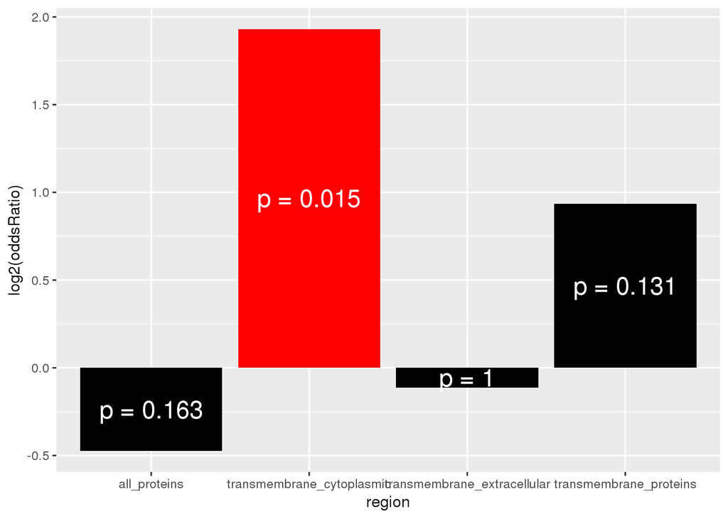

```r
mc <- motifChanges[SLiM == 'LIG_diLeu_1']

l <- list('all_proteins' = compareMotifChangesByVariantType(vars = variants,
                                  motifChanges = mc,
                                  changeType = 'gained'),
     'transmembrane_proteins' = compareMotifChangesByVariantType(
       vars =  variants[variants$uniprotAccession %in% tmProteins,],
                                  motifChanges = mc,
                                  changeType = 'gained'),
     'transmembrane_extracellular' = compareMotifChangesByVariantType(
       vars = variants[getVariantsByRegion(variants, etm),],
                                  motifChanges = mc,
                                  changeType = 'gained'),
     'transmembrane_cytoplasmic' = compareMotifChangesByVariantType(
       vars = variants[getVariantsByRegion(variants, ctm),],
                                  motifChanges = mc,
                                  changeType = 'gained'))
df <- do.call(rbind, lapply(names(l), function(r) {
  df <- l[[r]]
  df$region <- r
  return(df)
}))

ggplot2::ggplot(data = df,
                  aes(x = region, y = log2(oddsRatio))) +
    geom_bar(aes(fill = ifelse(pval < 0.05, 'red', 'black')), position = 'dodge', stat = 'identity') +
  geom_text(aes(label = paste('p =',round(pval, 3)),
                y = log2(oddsRatio)/2),
            color = 'white', size = 6) +
  scale_fill_identity()
```

## 4.2 Reproduce Figure 7C

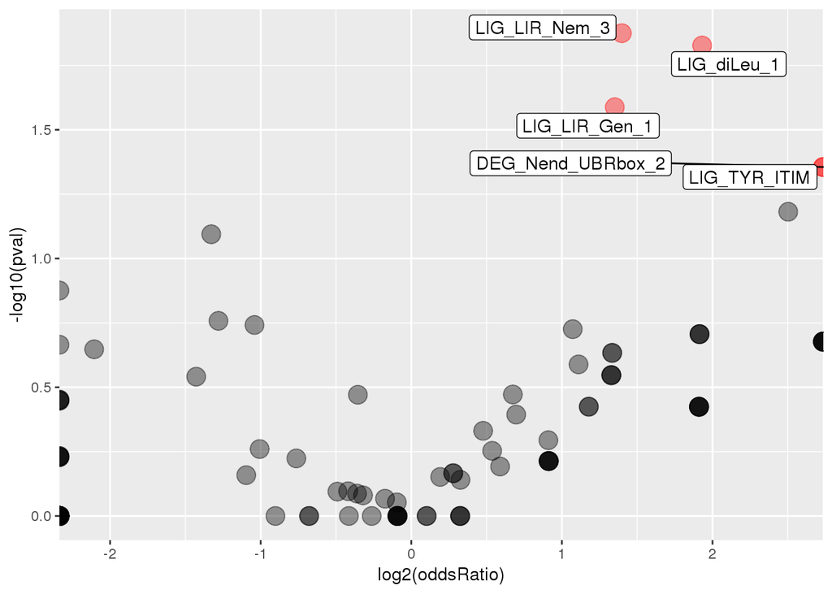

```r
#cytoplasmic regions of transmembrane proteins
vars = variants[getVariantsByRegion(variants, ctm),]
dt <- compareMotifChangesByVariantType(vars = vars, motifChanges = motifChanges, changeType = 'gained')
ggplot(dt, aes(x = log2(oddsRatio), y = -log10(pval))) +
  geom_point(aes(color = ifelse(pval < 0.05, 'red', 'black')), size = 5, alpha = 0.4) +
  geom_label_repel(aes(label = ifelse(pval < 0.05, SLiM, ''))) +
  scale_color_identity()
```